# Trust in political institutions and support for authoritarianism in Latin American students: Does civic knowledge make a difference?

- Institutional trust in National government and Civic Knowledge

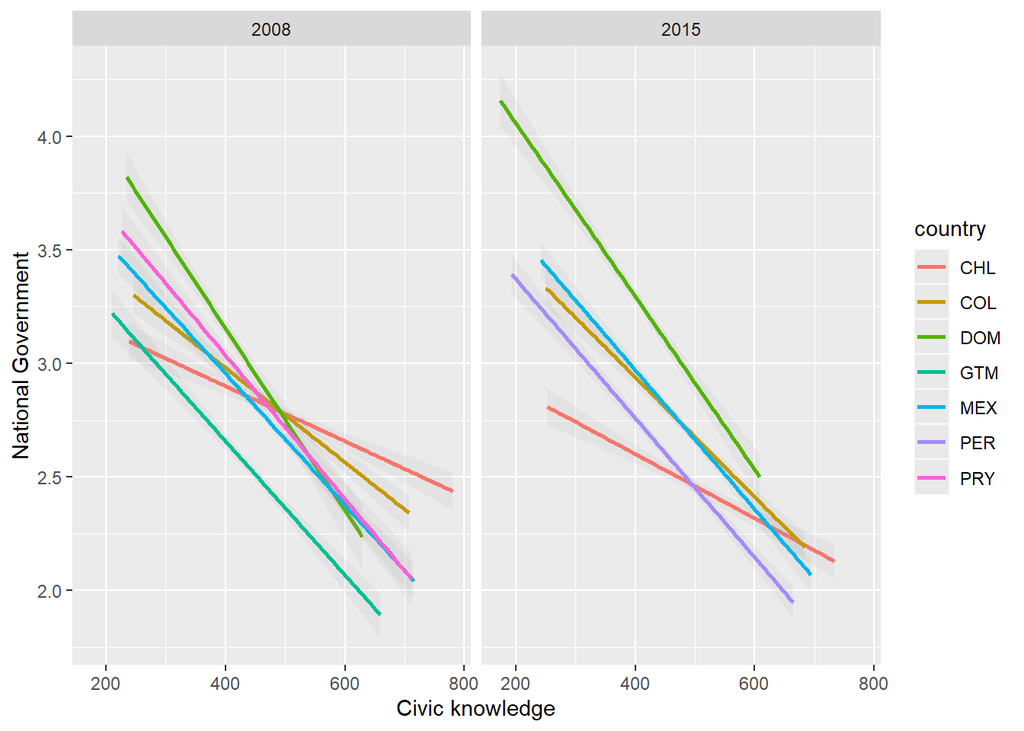

```r
dict2$test = as.numeric(dict2$civic_knowledge)
dict2$test2 = as.numeric(dict2$nac_gob)
graf <- ggplot(dict2, aes(x=test, y=test2, colour = factor(country)))  + geom_smooth(method = "lm", alpha = 0.1) +
        facet_wrap(~ time) +
        labs(y = "National Government", x = "Civic knowledge", colour = "country")
graf
```

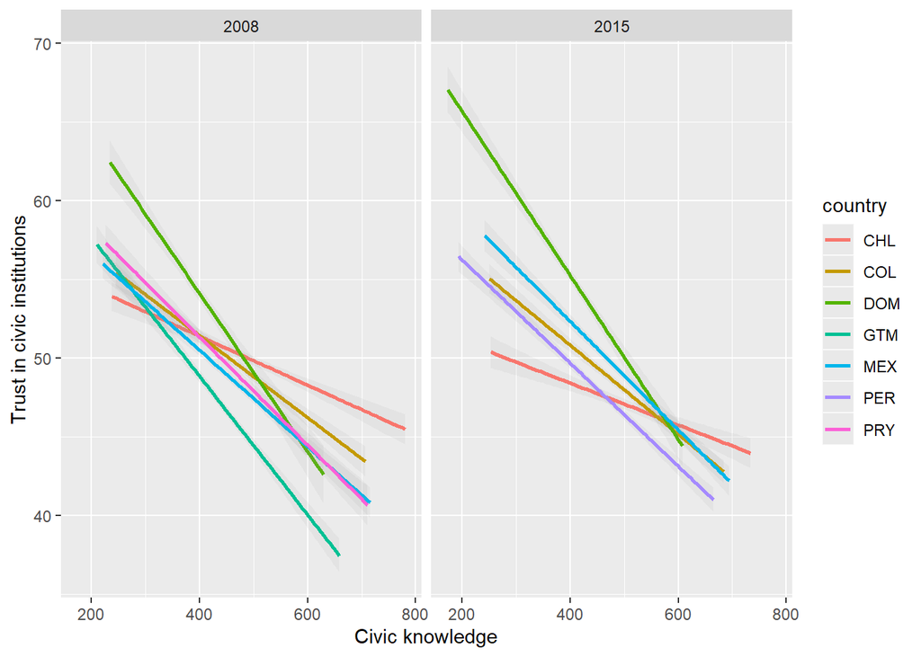

```r
dict2$test = as.numeric(dict2$civic_knowledge)
dict2$test2 = as.numeric(dict2$s_intrust)
graf <- ggplot(dict2, aes(x=test, y=test2, colour = factor(country)))  + geom_smooth(method = "lm", alpha = 0.1) +
        facet_wrap(~ time) +
        labs(y = "Trust in civic institutions", x = "Civic knowledge", colour = "country")
graf
```

```r
with(dict2,str(nac_gob))
```

```
##  num [1:41259] 3 4 3 2 3 3 3 3 4 2 ...
```

- Institutional trust in Local Goverment and Civic Knowledge

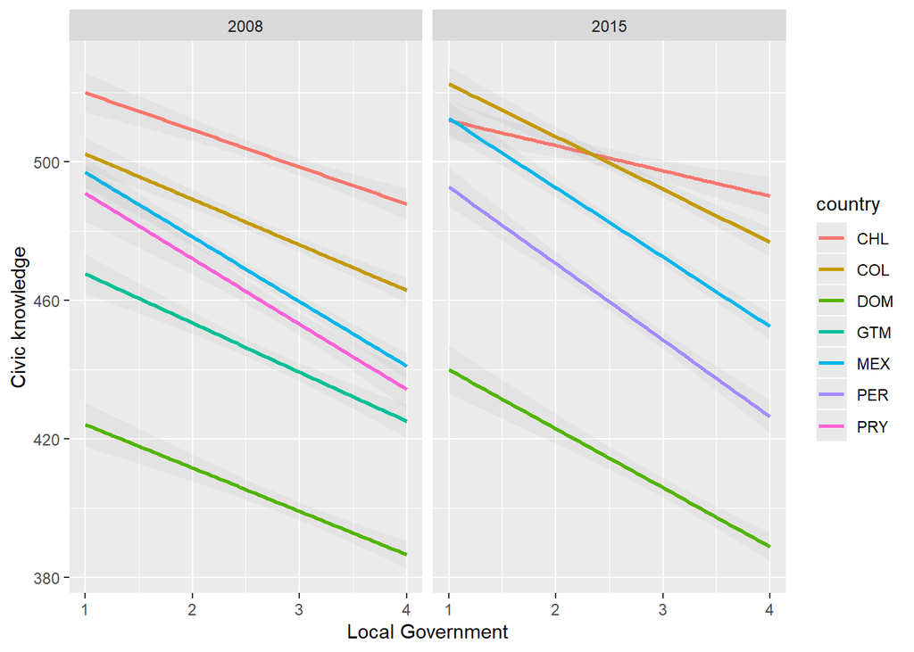

```r
    dict2$test = as.numeric(dict2$civic_knowledge)
dict2$test2 = as.numeric(dict2$local_gob)
graf <- ggplot(dict2, aes(x=test2, y=test, colour = factor(country)))  + geom_smooth(method = "lm", alpha = 0.1) +
        facet_wrap(~ time) +
        labs(x = "Local Government", y = "Civic knowledge", colour = "country")
graf
```

```r
with(dict2,str(local_gob))
```

```
##  num [1:41259] 2 4 2 2 3 3 3 3 4 3 ...
```

- Institutional trust in Courts of justicet and Civic Knowledge

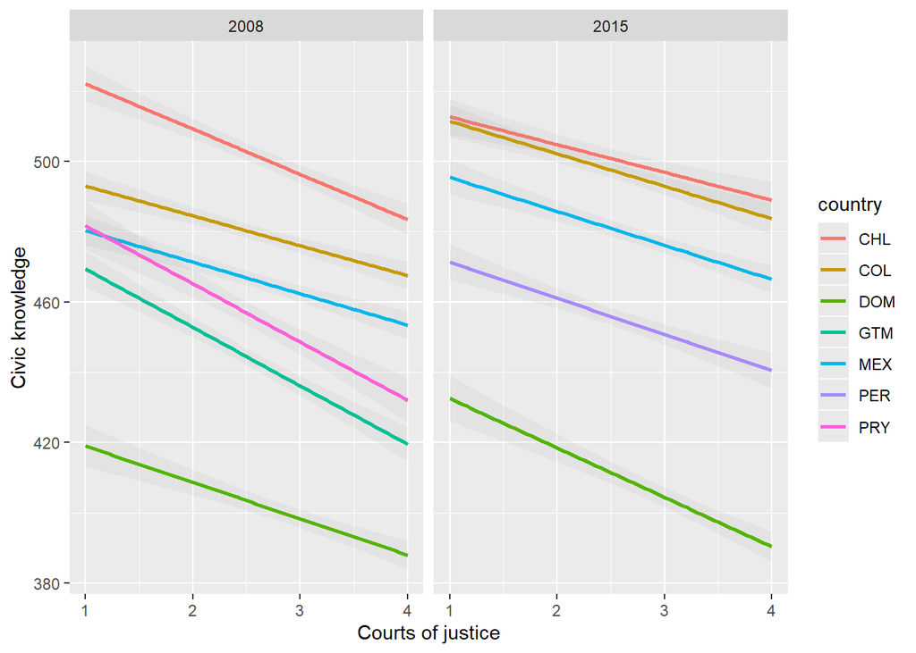

```r
    dict2$test = as.numeric(dict2$civic_knowledge)
dict2$test2 = as.numeric(dict2$courts)
graf <- ggplot(dict2, aes(x=test2, y=test, colour = factor(country)))  + geom_smooth(method = "lm", alpha = 0.1) +
        facet_wrap(~ time) +
        labs(x = "Courts of justice", y = "Civic knowledge", colour = "country")
graf
```

```r
with(dict2,str(courts))
```

```
##  num [1:41259] 2 3 3 3 3 3 3 3 4 3 ...
```

- Institutional trust in Police and Civic Knowledge

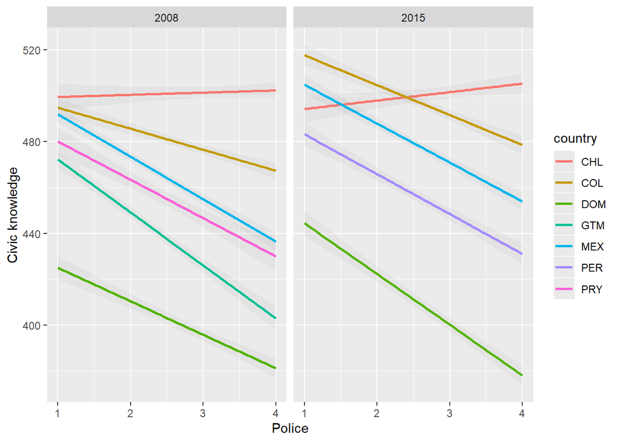

```r
   dict2$test = as.numeric(dict2$civic_knowledge)
dict2$test2 = as.numeric(dict2$police)
graf <- ggplot(dict2, aes(x=test2, y=test, colour = factor(country)))  + geom_smooth(method = "lm", alpha = 0.1) +
        facet_wrap(~ time) +
        labs(x = "Police", y = "Civic knowledge", colour = "country")
graf
```

```r
with(dict2,str(police))
```

```
##  num [1:41259] 3 4 4 4 3 4 2 3 4 3 ...
```

- Institutional trust in Political Parties and Civic Knowledge

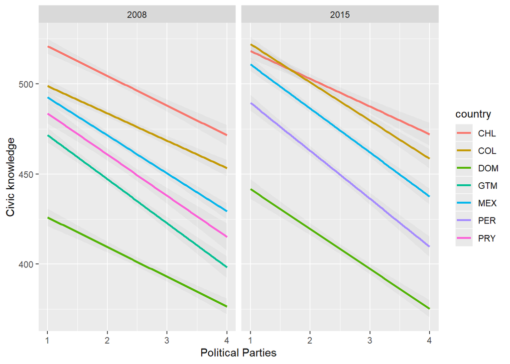

```r
   dict2$test = as.numeric(dict2$civic_knowledge)
dict2$test2 = as.numeric(dict2$pol_parties)
graf <- ggplot(dict2, aes(x=test2, y=test, colour = factor(country)))  + geom_smooth(method = "lm", alpha = 0.1) +
        facet_wrap(~ time) +
        labs(x = "Political Parties", y = "Civic knowledge", colour = "country")
graf
```

```r
with(dict2,str(pol_parties))
```

```
##  num [1:41259] 1 3 2 2 2 3 1 3 3 2 ...
```

- Institutional trust in National Parliament and Civic Knowledge

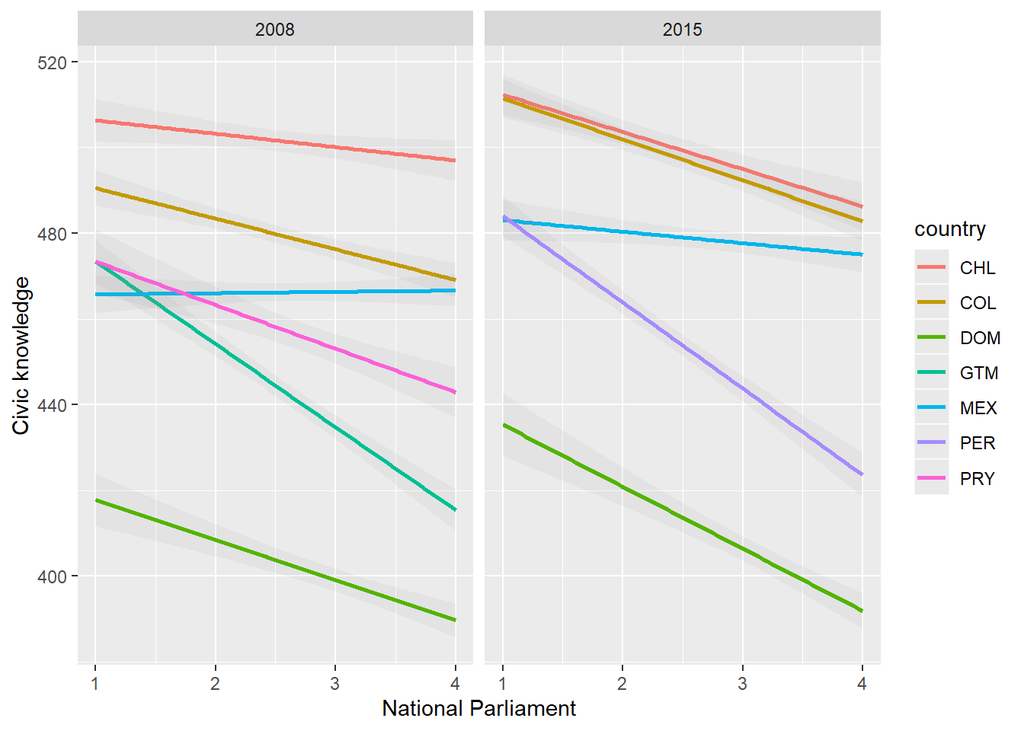

```r
 dict2$test = as.numeric(dict2$civic_knowledge)
dict2$test2 = as.numeric(dict2$parliament)
graf <- ggplot(dict2, aes(x=test2, y=test, colour = factor(country)))  + geom_smooth(method = "lm", alpha = 0.1) +
        facet_wrap(~ time) +
        labs(x = "National Parliament", y = "Civic knowledge", colour = "country")
graf
```

```r
with(dict2,str(parliament))
```

```
##  num [1:41259] 1 3 2 3 3 3 3 3 3 2 ...
```

- Institutional trust in Media and Civic Knowledge

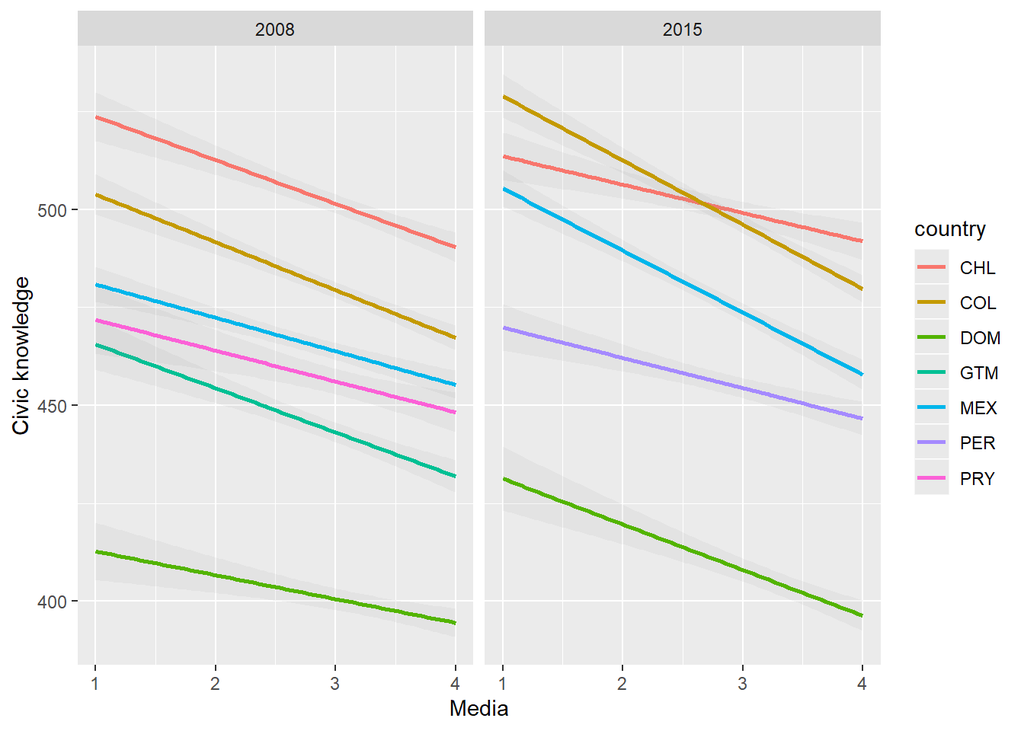

```r
 dict2$test = as.numeric(dict2$civic_knowledge)
dict2$test2 = as.numeric(dict2$media)
graf <- ggplot(dict2, aes(x=test2, y=test, colour = factor(country)))  + geom_smooth(method = "lm", alpha = 0.1) +
        facet_wrap(~ time) +
        labs(x = "Media", y = "Civic knowledge", colour = "country")
graf
```

```r
with(dict2,str(media))
```

```
##  num [1:41259] 2 4 1 4 2 3 3 3 2 2 ...
```

- Institutional trust in FFAA and Civic Knowledge

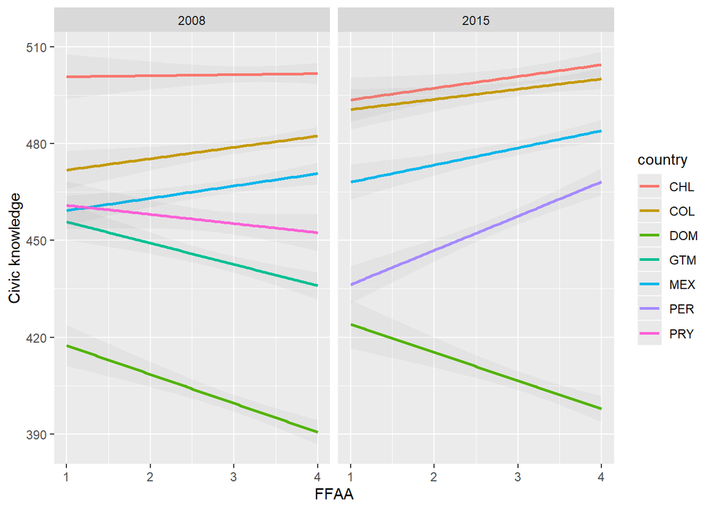

```r
 dict2$test = as.numeric(dict2$civic_knowledge)
dict2$test2 = as.numeric(dict2$ffaa)
graf <- ggplot(dict2, aes(x=test2, y=test, colour = factor(country)))  + geom_smooth(method = "lm", alpha = 0.1) +
        facet_wrap(~ time) +
        labs(x = "FFAA", y = "Civic knowledge", colour = "country")
graf
```

```r
with(dict2,str(ffaa))
```

```
##  num [1:41259] 4 4 1 4 3 4 3 3 4 2 ...
```

- Institutional trust in School and Civic Knowledge

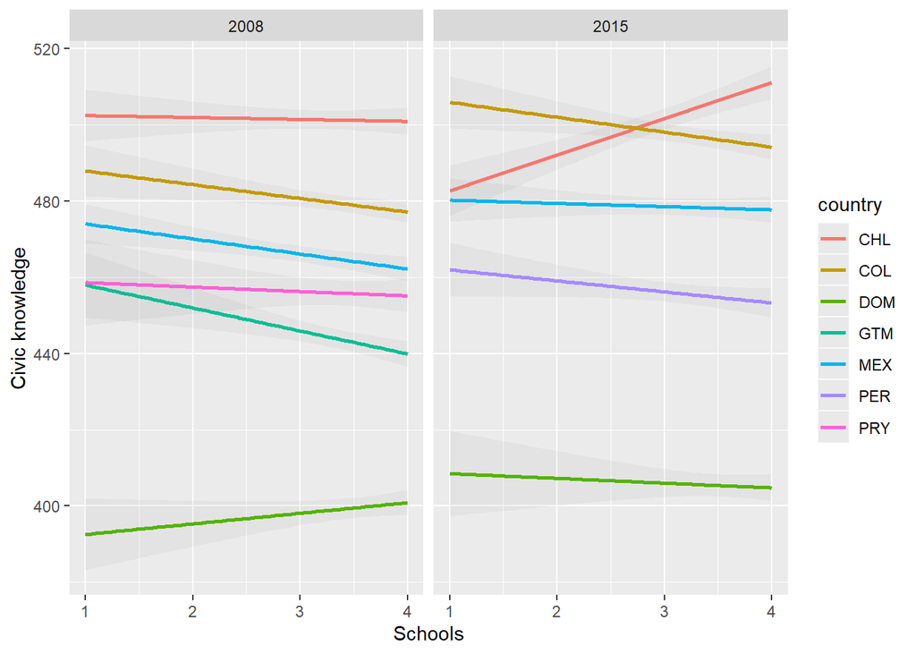

```r
 dict2$test = as.numeric(dict2$civic_knowledge)
dict2$test2 = as.numeric(dict2$school)
graf <- ggplot(dict2, aes(x=test2, y=test, colour = factor(country)))  + geom_smooth(method = "lm", alpha = 0.1) +
        facet_wrap(~ time) +
        labs(x = "Schools", y = "Civic knowledge", colour = "country")
graf
```

```r
with(dict2,str(school))
```

```
##  num [1:41259] 4 4 1 4 4 4 3 3 4 2 ...
```

- Institutional trust in people and Civic Knowledge

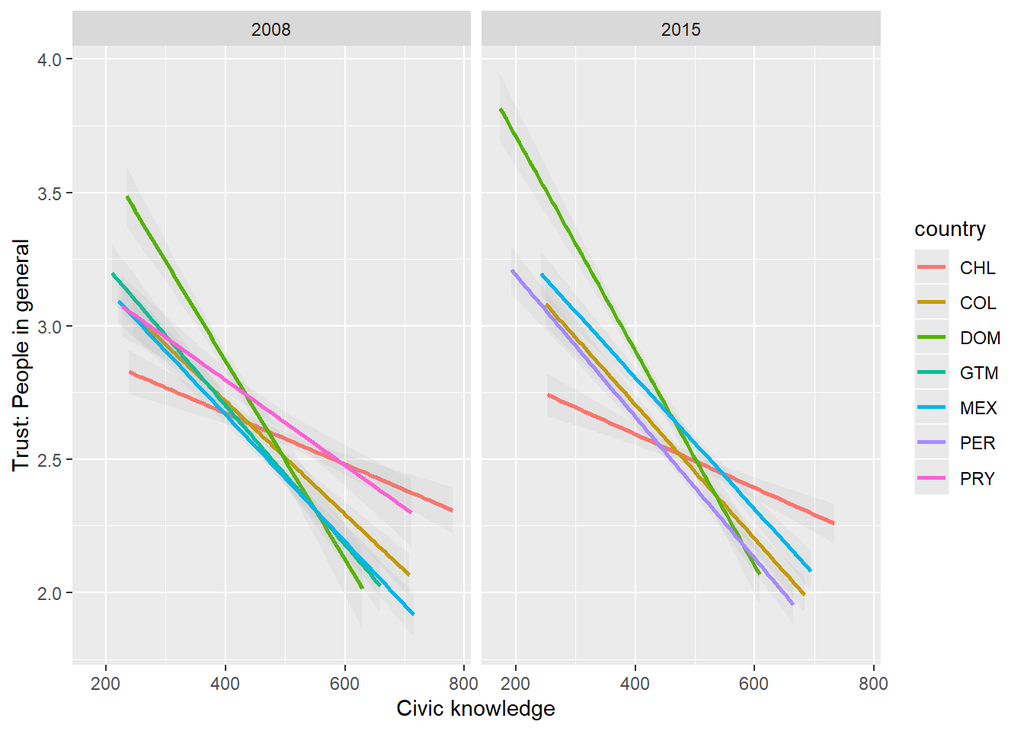

```r
 dict2$test = as.numeric(dict2$civic_knowledge)
dict2$test2 = as.numeric(dict2$people)
graf <- ggplot(dict2, aes(x=test, y=test2, colour = factor(country)))  + geom_smooth(method = "lm", alpha = 0.1) +
        facet_wrap(~ time) +
        labs(x = "Civic knowledge", y = "Trust: People in general", colour = "country")
graf
```

```r
with(dict2,str(people))
```

```
##  num [1:41259] 4 3 1 3 2 4 1 3 3 2 ...
```

- Institutional trust index and Civic Knowledge

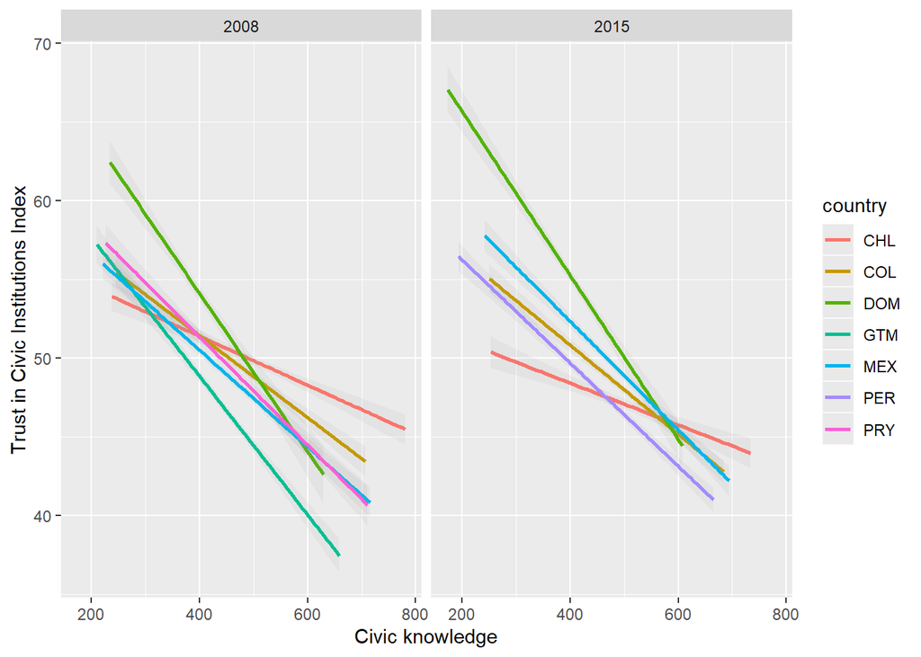

```r
 dict2$test = as.numeric(dict2$civic_knowledge)
dict2$test2 = as.numeric(dict2$s_intrust)
graf <- ggplot(dict2, aes(x=test, y=test2, colour = factor(country)))  + geom_smooth(method = "lm", alpha = 0.1) +
        facet_wrap(~ time) +
        labs(x = "Civic knowledge", y = "Trust in Civic Institutions Index", colour = "country")
graf
```

```r
with(dict2,str(people))
```

```
##  num [1:41259] 4 3 1 3 2 4 1 3 3 2 ...
```

- Interaction between trust and civic knowledge on dictatorship support

```r
library(sjPlot)
dict2$test = as.numeric(dict2$civic_knowledge)
dict2$test2 = as.numeric(dict2$s_intrust)

chile= dict2 %>%
       dplyr::filter(country=="CHL" & time=="2015")

names(dict09)
```

```
##  [1] "time"            "country"         "idcountry"
##  [4] "idschool"        "idstudent"       "dict_safety"
##  [7] "dict_benefits"   "dict"            "pv1civ"
## [10] "pv2civ"          "pv3civ"          "pv4civ"
## [13] "pv5civ"          "civic_knowledge" "s_intrust"
## [16] "s_opdisc"        "s_hisced"        "univ"
## [19] "s_hisei"         "s_homelit"       "s_gender"
## [22] "s_citcon"        "s_citsoc"        "s_citeff"
## [25] "s_cntatt"        "s_geneql"        "s_ethrght"
## [28] "l_attviol"       "l_attdiv"        "l_autgov"
## [31] "l_attcorr"       "l_dislaw"        "l_empclas"
## [34] "s_poldisc"       "nac_gob"         "local_gob"
## [37] "courts"          "police"          "pol_parties"
## [40] "parliament"      "media"           "ffaa"
## [43] "school"          "unit_nations"    "people"
## [46] "totwgts"         "wgtfac1"         "wgtadj1s"
## [49] "wgtfac2s"        "wgtadj2s"        "wgtadj3s"
## [52] "jkzones"         "jkreps"
```

```r
fit= lm(l_autgov~ s_intrust*civic_knowledge + s_hisced + s_homelit + s_gender + s_poldisc+ time, data=dict2, w=totwgts)

summary(fit)
```

```
##
## Call:
## lm(formula = l_autgov ~ s_intrust * civic_knowledge + s_hisced +
##     s_homelit + s_gender + s_poldisc + time, data = dict2, weights = totwgts)
##
## Weighted Residuals:
##      Min       1Q   Median       3Q      Max
## -1157.26   -36.51     5.96    44.62   833.50
##
## Coefficients:
##                                Estimate    Std. Error t value
## (Intercept)               -212.49929668   25.49606943  -8.335
## s_intrust                    0.27888613    0.02432407  11.465
## civic_knowledge             -0.06570725    0.00264038 -24.886
## s_hisced                     0.04672235    0.03158842   1.479
## s_homelit                   -0.18085329    0.04051330  -4.464
## s_gender                    -1.15078216    0.08507347 -13.527
## s_poldisc                   -0.01892121    0.00447721  -4.226
## time                         0.14211495    0.01268992  11.199
## s_intrust:civic_knowledge   -0.00026525    0.00005247  -5.055
##                                       Pr(>|t|)
## (Intercept)               < 0.0000000000000002 ***
## s_intrust                 < 0.0000000000000002 ***
## civic_knowledge           < 0.0000000000000002 ***
## s_hisced                                 0.139
## s_homelit                          0.000008064 ***
## s_gender                  < 0.0000000000000002 ***
## s_poldisc                          0.000023826 ***
## time                      < 0.0000000000000002 ***
## s_intrust:civic_knowledge          0.000000431 ***
## ---
## Signif. codes:  0 '***' 0.001 '**' 0.01 '*' 0.05 '.' 0.1 ' ' 1
##
## Residual standard error: 98.87 on 41250 degrees of freedom
## Multiple R-squared:  0.3929, Adjusted R-squared:  0.3928
## F-statistic:  3337 on 8 and 41250 DF,  p-value: < 0.00000000000000022
```

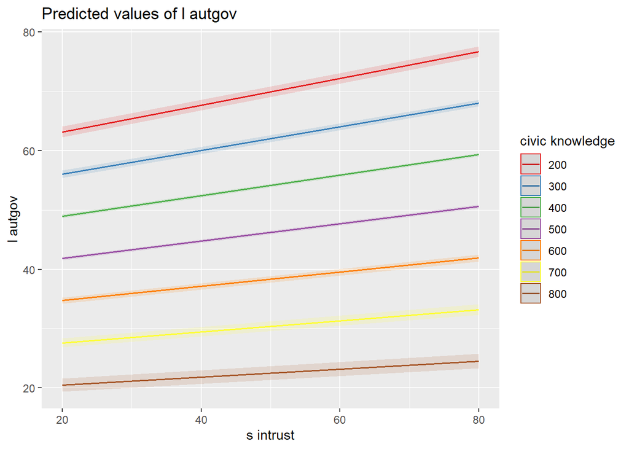

```r
plot_model(fit, type = "pred", terms = c("s_intrust[20,80]", "civic_knowledge[200, 300, 400, 500, 600, 700, 800]"))
```

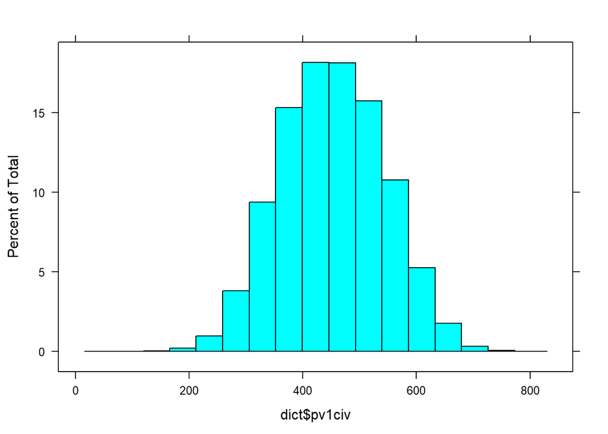

```r
histogram(dict$pv1civ)
```

- Multilevel SEM

```r
#names(dict2)
library(lavaan)
dict2$know = dict2$civic_knowledge/100 #Reescalar conocimiento cívico
dict2$eduxknow = dict2$univ*dict2$know

#str(dict2)
chile= dict2 %>%
       dplyr::filter(country=="CHL" & time=="2015")

#skim(chile)

 model1 <- '
        level: 1
            s_intrust ~ know + univ
            dict ~ know + univ
        level: 2
            s_intrust ~~ dict
            nac_gob ~~ know
            dict ~~ know
    '

    fit1 <- sem(model = model1, data = chile, cluster = "idschool")
    summary(fit1)
```

```
## lavaan 0.6-3 ended normally after 63 iterations
##
##   Optimization method                           NLMINB
##   Number of free parameters                         18
##
##   Number of observations                          4070
##   Number of clusters [idschool]                    175
##
##   Estimator                                         ML
##   Model Fit Test Statistic                     209.781
##   Degrees of freedom                                 3
##   P-value (Chi-square)                           0.000
##
## Parameter Estimates:
##
##   Information                                 Observed
##   Observed information based on                Hessian
##   Standard Errors                             Standard
##
##
## Level 1 [within]:
##
## Regressions:
##                    Estimate  Std.Err  z-value  P(>|z|)
##   s_intrust ~
##     know             -1.780    0.243   -7.318    0.000
##     univ              0.124    0.419    0.296    0.768
##   dict ~
##     know             -0.271    0.020  -13.904    0.000
##     univ             -0.098    0.036   -2.714    0.007
##
## Covariances:
##                    Estimate  Std.Err  z-value  P(>|z|)
##  .s_intrust ~~
##    .dict              1.277    0.147    8.677    0.000
##
## Intercepts:
##                    Estimate  Std.Err  z-value  P(>|z|)
##    .s_intrust         0.000
##    .dict              0.000
```

[output cut: 16 more lines]

```
##     know             -0.087    0.014   -6.099    0.000
##
## Intercepts:
##                    Estimate  Std.Err  z-value  P(>|z|)
##    .s_intrust        47.080    0.255  184.579    0.000
##     know              4.941    0.042  117.388    0.000
##    .dict              2.485    0.026   97.292    0.000
##     nac_gob           2.481    0.020  122.352    0.000
##
## Variances:
##                    Estimate  Std.Err  z-value  P(>|z|)
##    .s_intrust         5.421    1.151    4.708    0.000
##     know              0.284    0.033    8.488    0.000
##    .dict              0.074    0.013    5.652    0.000
##     nac_gob           0.072    0.008    9.354    0.000
```

```r
    model2 <- '
        level: 1
            nac_gob ~ know + univ + eduxknow
            dict ~ know + univ + eduxknow
        level: 2
            nac_gob ~~ dict
            nac_gob ~~ know
            dict ~~ know
    '

    fit2 <- sem(model = model2, data = chile, cluster = "idschool")
    summary(fit2)
```

[output not shown]

[output cut: 15 more lines]

```
##     know             -0.038    0.011   -3.483    0.000
##  .dict ~~
##     know             -0.072    0.013   -5.444    0.000
##
## Intercepts:
##                    Estimate  Std.Err  z-value  P(>|z|)
##    .nac_gob           2.467    0.021  120.319    0.000
##    .dict              2.481    0.023  106.424    0.000
##     know              4.945    0.037  134.404    0.000
##
## Variances:
##                    Estimate  Std.Err  z-value  P(>|z|)
##    .nac_gob           0.034    0.007    4.590    0.000
##    .dict              0.055    0.010    5.447    0.000
##     know              0.216    0.025    8.489    0.000
```